# Monitoria 2 Problemas de Especificacao

Giovanna Quintão

20 de setembro de 2020

# Introdução

Vamos instalar os pacotes que ainda não utilizamos e vamos requisitar todos os pacotes

```r
#install.packages("srvyr")
#install.packages("stargazer")
#install.packages("survey")
library(survey)
library(srvyr) #pacote para construir o plano amostral
library(dplyr) #pacote para arrumar a base de dados
library(stargazer) #pacote para mostrar os resultados das regressões


options(scipen = 999)
```

Vamos abrir a base de dados. A base é a PNAD Covid -Julho ORIGINAL.

Por isso vamos ter que fazer alguns ajustes antes de começar a trabalhar.

Você pode conferir todas as informações no site do [IBGE](https://covid19.ibge.gov.br/pnad-covid/)

```r
PNAD <- read.csv("PNAD_COVID_072020.csv")
```

# Plano amostral

Vamos fazer o plano amostral

```r
pnad_svy <-
  PNAD %>% as_survey_design(
    ids = UPA,
    #declara a unidade amostral mais granular
    strata = Estrato,
    #declara o estrato
    weights = V1032,
    #declara os pesos
    nest = TRUE # declara que os estratos podem conter identificações identicas para UPAs distintas
  )
```

Vamos renomear as variáveis que precisamos (as variáveis estão descritas no dicionário)

```r
pnad_svy <- pnad_svy %>%
  rename(
    renda = C011A12,
    sexo = A003,
    idade = A002,
    raca = A004,
    escolaridade = A005
  )
```

Vamos recriar as variáveis de sexo, raça, escolaridade e idade^2 para ficar mais fácil de trabalharmos.

```r
pnad_svy$variables <- pnad_svy$variables %>%
  mutate(raca_branco = ifelse(raca == 1, 1, 0),#olhar no dicionário a definição
         sexo_homem = ifelse(sexo == 1, 1, 0)) %>%
  mutate(
    esc = ifelse(
      escolaridade == 1,
      "Sem instrução",
      ifelse(
        escolaridade == 2,
        "Fund.incompleto",
        ifelse(
          escolaridade == 3,
          "Fund.completo",
          ifelse(
            escolaridade == 4,
            "EM.incompleto",
            ifelse(
              escolaridade == 5,
              "EM.completo",
              ifelse(
                escolaridade == 6,
                "Superior incompleto",
                ifelse(
                  escolaridade == 7,
                  "Superior completo",
                  ifelse(escolaridade == 8,
                         "Pós-graduação+", NA)
                )
              )
            )
          )
        )
      )
    )) %>%
  mutate(esc=factor(esc,levels=c("Sem instrução","Fund.incompleto","Fund.completo",
                                    "EM.incompleto","EM.completo","Superior incompleto","Superior completo",
                                    "Pós-graduação+"))) %>%
  mutate(idade2=idade^2)
```

Vamos fazer a regressão de salário e salvar a regressão

```r
reg_svy_BR <-
      svyglm(
        renda ~ sexo_homem + raca_branco + esc + idade + idade2,
        design = pnad_svy%>% filter(idade>=18&is.na(renda)==F&renda>0)
      )
```

Vamos fazer a mesma regressão mas usando só a cidade de SP e salvar a regressão

```r
reg_svy_SP <-
      svyglm(
        renda ~ sexo_homem + raca_branco + esc + idade + idade2,
        design = pnad_svy %>% filter(idade>=18&CAPITAL==35&is.na(renda)==F&renda>0)
      )
```

# Pesos

Uma outra forma de estimar de forma mais simples, embora não totalmente correta, é usar somente os pesos na regressão.

Vamos fazer isso para comparar com a estimação do plano amostral

Mas para fazer isso, precisamos arrumar a base de dados da mesma forma que arrumamos anteriormente (mas antes arrumamos já a base no plano amostral, agora vamos arrumar a base original )

```r
PNAD <- PNAD %>%
  rename(
    renda = C011A12,
    sexo = A003,
    idade = A002,
    raca = A004,
    escolaridade = A005
  )

PNAD<-PNAD %>%
  mutate(raca_branco = ifelse(raca == 1, 1, 0),
         sexo_homem = ifelse(sexo == 1, 1, 0)) %>%
  mutate(
    esc = ifelse(
      escolaridade == 1,
      "Sem instrução",
      ifelse(
        escolaridade == 2,
        "Fund.incompleto",
        ifelse(
          escolaridade == 3,
          "Fund.completo",
          ifelse(
            escolaridade == 4,
            "EM.incompleto",
            ifelse(
              escolaridade == 5,
              "EM.completo",
              ifelse(
                escolaridade == 6,
                "Superior incompleto",
                ifelse(
                  escolaridade == 7,
                  "Superior completo",
                  ifelse(escolaridade == 8,
                         "Pós-graduação+", NA)
                )
              )
            )
          )
        )
      )
    )) %>%
  mutate(esc=factor(esc,levels=c("Sem instrução","Fund.incompleto","Fund.completo",
                                 "EM.incompleto","EM.completo","Superior incompleto","Superior completo",
                                 "Pós-graduação+"))) %>%
  mutate(idade2=idade^2)
```

Vamos estimar para o Brasil inteiro usando os peso e salvar a regressão

```r
reg_peso_BR <-
  lm(
    renda ~ sexo_homem + raca_branco + esc + idade + idade2,weights = V1032,#variavel de peso pessoa
    PNAD%>% filter(idade>=18&is.na(renda)==F&renda>0)
  )
```

Vamos estimar para São Paulo usando os peso e salvar a regressão

```r
reg_peso_SP<-
  lm(
    renda ~ sexo_homem + raca_branco + esc + idade + idade2,weights = V1032,
    PNAD%>% filter(idade>=18&CAPITAL==35)
  )
```

# Comparação das estimações

```r
stargazer(reg_svy_BR,reg_peso_BR,reg_svy_SP,reg_peso_SP,type="text",
                  column.labels =c("Survey BR","Peso BR","Survey SP","Peso SP"))
```

```
##
## ===============================================================================================================
##                                                          Dependent variable:
##                        ----------------------------------------------------------------------------------------
##                                                                 renda
##                        survey-weighted              OLS               survey-weighted            OLS
##                            normal                                         normal
##                           Survey BR               Peso BR                Survey SP             Peso SP
##                              (1)                    (2)                     (3)                  (4)
## ---------------------------------------------------------------------------------------------------------------
## sexo_homem               847.310***              847.310***            1,145.857***         1,087.585***
##                           (23.242)                (15.274)               (160.181)            (154.208)
##
## raca_branco              453.869***              453.869***             583.669***           540.077***
##                           (25.009)                (15.149)               (137.818)            (164.461)
##
## escFund.incompleto       476.437***              476.437***               340.814              200.360
##                           (29.253)                (72.440)               (325.894)           (1,343.103)
##
## escFund.completo         798.650***              798.650***              737.226**             498.429
##                           (33.063)                (75.718)               (372.489)           (1,355.389)
##
## escEM.incompleto        1,017.503***            1,017.503***             872.051**             639.479
##                           (35.908)                (75.760)               (361.929)           (1,352.825)
##
## escEM.completo          1,278.228***            1,278.228***           1,240.081***           1,014.022
##                           (35.065)                (71.854)               (360.494)           (1,327.152)
##
## escSuperior incompleto  1,855.230***            1,855.230***           2,557.770***          2,246.450*
##                           (51.013)                (75.879)               (477.106)           (1,347.977)
##
## escSuperior completo    3,305.685***            3,305.685***           4,556.044***         4,284.798***
##                           (64.480)                (72.850)               (469.399)           (1,329.733)
##
## escPós-graduação+       5,749.618***            5,749.618***           8,074.522***         7,289.229***
##                           (168.083)               (77.032)               (752.948)           (1,345.588)
##
## idade                     75.576***              75.576***               123.925**           126.487***
##                            (6.724)                (3.560)                (49.295)             (34.862)
##
## idade2                    -0.498***              -0.498***                -0.858              -0.993**
##                            (0.085)                (0.042)                 (0.585)              (0.396)
##
## Constant                -2,427.392***          -2,427.392***           -3,787.723***        -3,506.222**
##                           (127.053)              (101.725)              (1,023.242)          (1,507.154)
##
## ---------------------------------------------------------------------------------------------------------------
## Observations               129,607                129,607                  3,146                3,364
## R2                                                 0.239                                        0.228
## Adjusted R2                                        0.239                                        0.226
## Log Likelihood         -1,224,423.000                                   -31,106.150
## Akaike Inf. Crit.       2,448,871.000                                   62,236.290
## Residual Std. Error                       63,718.640 (df = 129595)                     175,200.000 (df = 3352)
## F Statistic                            3,709.829*** (df = 11; 129595)                 90.115*** (df = 11; 3352)
## ===============================================================================================================
## Note:                                                                               *p<0.1; **p<0.05; ***p<0.01
```

# Teste RESET

A partir de agora vamos usar somente a estimação do Survey para o município de SP

Será que a forma da variável dependente está especificada de forma correta?

Vamos fazer o teste RESET para verificar se a forma funcional está especificada corretamente.

Seja os dois modelos:

$$\textbf{Modelo irrestrito}:$$
$$salário=\beta_0+\beta_1idade+\beta_2idade^2+\beta_3sexo+\beta_4raça+\beta_5escolaridade+\delta_1\hat{y^2}+\delta_2\hat{y^3}+erro$$

$$\textbf{Modelo restrito}:$$
$$salário=\beta_0+\beta_1idade+\beta_2idade^2+\beta_3sexo+\beta_4raça+\beta_5escolaridade+erro$$

Queremos testar:

$$H0: \delta_1, \delta_2=0 \text{ (não há má especificação)}$$
$$H1: \delta_1, \delta_2\neq0 \text{ (há má especificação)}$$

Agora vamos fazer o teste !

**a) Primeiro, vamos construir as variaveis preditas:**

```r
pnad_svy_SP<-pnad_svy %>%
  filter(CAPITAL==35&idade>=18&is.na(renda)==F&renda>0)
#fazendo filtros para a base do survey ficar igual a base que fizemos a regressão

pnad_svy_SP$variables$fitted2<-predict(reg_svy_SP)^2
pnad_svy_SP$variables$fitted3<-predict(reg_svy_SP)^3
```

**b) Vamos estimar o modelo com as variáveis preditas**

```r
MQO_irr<-svyglm(
        renda ~ sexo_homem + raca_branco + esc + idade + idade2+fitted2+fitted3,
        design = pnad_svy_SP
      )
```

**c) Vamos calcular a estatística F**

Lembrando que a estatistica F é a do teste de H0: delta_1=0,delta_2=0

$$\begin{equation}
F=\frac{(SSE_{R}-SSE_{U})\,/\,J}{SSE_{U}\,/\,(n-k)} \sim F_{(J,\;N-K)}
\label{eq:FstatFormula6}
\end{equation}$$

Lembrando quais são nossos modelos restritos e irrestritos Modelo irrestrito: MQO_irr

Modelo restrito: reg_svy_SP

```r
#Vamos calcular a soma dos resíduos
res1 <- reg_svy_SP$residuals
res2 <- MQO_irr$residuals
res1 <- sum(res1^2)
res2 <- sum(res2^2)

J<-2
n<-as.numeric(length(MQO_irr$fitted.values))
k<-6

F<-((res1 - res2)/J) / (res2/(n-k))

print(F)
```

```
## [1] 49.29
```

**c) Vamos fazer o teste F**

Primeiro vamos ver a distribuição F com df1=2 e df2=n-k-3

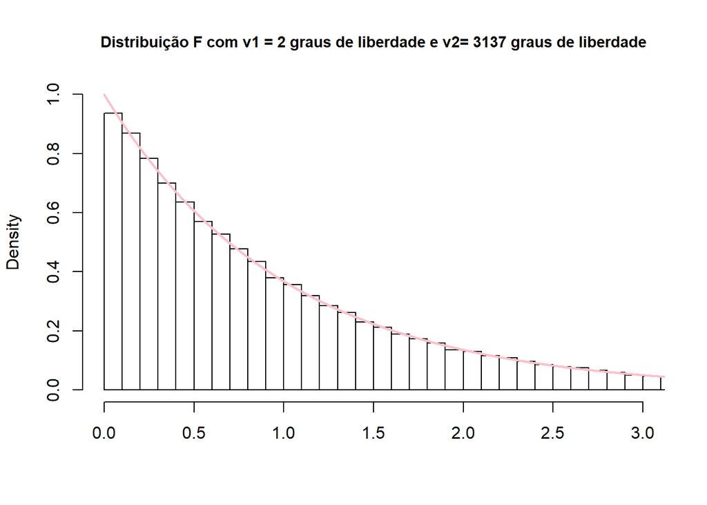

```r
df1<-2
df2<-n-k-3

x <- rf(100000, df1 = df1, df2 = df2)
hist(x,
     breaks = 'Scott',
     freq = FALSE,
     xlim = c(0,3),
     ylim = c(0,1),
     xlab = '',
     main = (paste0("Distribuição F com v1 = ", df1, " graus de liberdade e v2= ",df2," graus de liberdade")), cex.main=0.9)

curve(df(x, df1 = df1, df2 = df2), from = 0, to = 4, n = 5000, col= 'pink', lwd=2, add = T)
```

```r
df(F,2,n-k-3) #função densidade
```

```
## [1] 0.0000000000000000000008121739
```

Rejeita-se a hipótese nula, ou seja rejeita-se que os dois coeficientes são conjuntamente iguais a zero. Portanto, *há evidência de má-especificação da variável dependente*.

Uma forma de especificação da variável dependente mais adequada seria fazer em termos de log. Poderíamos estimar:

```r
reg_svy_SP_log <-
      svyglm(
        log(renda) ~ sexo_homem + raca_branco + esc + idade + idade2,
        design = pnad_svy_SP
      )

stargazer(reg_svy_SP_log,type="text")
```

```
##
## ==================================================
##                            Dependent variable:
##                        ---------------------------
##                                log(renda)
## --------------------------------------------------
## sexo_homem                      0.298***
##                                  (0.027)
##
## raca_branco                     0.103***
##                                  (0.032)
##
## escFund.incompleto                0.592
##                                  (0.428)
##
## escFund.completo                 0.814*
##                                  (0.446)
##
## escEM.incompleto                 0.759*
##                                  (0.440)
##
## escEM.completo                   0.957**
##                                  (0.441)
##
## escSuperior incompleto          1.324***
##                                  (0.440)
##
## escSuperior completo            1.805***
##                                  (0.439)
##
## escPós-graduação+               2.329***
##                                  (0.443)
##
## idade                           0.032***
##                                  (0.007)
##
## idade2                         -0.0003***
##                                 (0.0001)
##
## Constant                        5.274***
##                                  (0.452)
##
## --------------------------------------------------
## Observations                      3,146
## Log Likelihood                 -3,892.854
## Akaike Inf. Crit.               7,809.707
## ==================================================
## Note:                  *p<0.1; **p<0.05; ***p<0.01
```

# Testes contra alternativas não aninhadas

Vamos ver a relação entre teletrabalho e renda,escolaridade, idade, sexo e raça.

$$\text{teletrabalho}=\beta_0+\beta_1renda+\beta_2escolaridade+\beta_3idade+\beta_4idade2+\beta_5sexo+\beta_6raça+\epsilon \qquad (1)$$

Vamos criar a variável

```r
pnad_svy_SP$variables<-pnad_svy_SP$variables %>%
  mutate(teletrabalho=ifelse(C013==1,1,0),
         teletrabalho=ifelse(is.na(teletrabalho)==T,0,teletrabalho))
```

Por mais que seja uma variável binária, vamos usar um modelo linear

```r
MQO<-svyglm(teletrabalho ~renda+ sexo_homem + raca_branco + esc + idade + idade2,design=pnad_svy_SP)

stargazer(MQO,type="text")
```

```
##
## ==================================================
##                            Dependent variable:
##                        ---------------------------
##                               teletrabalho
## --------------------------------------------------
## renda                           0.00001**
##                                 (0.00000)
##
## sexo_homem                      -0.048***
##                                  (0.018)
##
## raca_branco                     0.079***
##                                  (0.017)
##
## escFund.incompleto               -0.020
##                                  (0.016)
##
## escFund.completo                 -0.024
##                                  (0.021)
##
## escEM.incompleto                 -0.029
##                                  (0.022)
##
## escEM.completo                    0.021
##                                  (0.019)
##
## escSuperior incompleto          0.232***
##                                  (0.038)
##
## escSuperior completo            0.377***
##                                  (0.029)
##
## escPós-graduação+               0.497***
##                                  (0.041)
##
## idade                           -0.009**
##                                  (0.004)
##
## idade2                           0.0001*
##                                 (0.00004)
##
## Constant                        0.272***
##                                  (0.083)
##
## --------------------------------------------------
## Observations                      3,146
## Log Likelihood                 -1,674.625
## Akaike Inf. Crit.               3,375.250
## ==================================================
## Note:                  *p<0.1; **p<0.05; ***p<0.01
```

Mas será que a renda não deveria estar em forma logaritimica?

Queremos testar (1) contra

$$\text{teletrabalho}=\beta_0+\beta_1log(renda)+\beta_2escolaridade+\beta_3idade+\beta_4idade2+\beta_5sexo+\beta_6raça+\epsilon \qquad (2)$$

Vamos fazer o teste de Davidson-MacKinnon. Primeiro vamos estimar (2) e salvar o valor predito

```r
MQO2<-svyglm(teletrabalho ~log(renda)+ sexo_homem + raca_branco + esc + idade + idade2,design=pnad_svy_SP)

pnad_svy_SP$variables$fitted<-MQO2$fitted


stargazer(MQO2,type="text")
```

```
##
## ==================================================
##                            Dependent variable:
##                        ---------------------------
##                               teletrabalho
## --------------------------------------------------
## log(renda)                      0.053***
##                                  (0.010)
##
## sexo_homem                      -0.057***
##                                  (0.019)
##
## raca_branco                     0.077***
##                                  (0.017)
##
## escFund.incompleto               -0.049
##                                  (0.031)
##
## escFund.completo                 -0.062*
##                                  (0.034)
##
## escEM.incompleto                 -0.064*
##                                  (0.035)
##
## escEM.completo                   -0.022
##                                  (0.033)
##
## escSuperior incompleto          0.177***
##                                  (0.044)
##
## escSuperior completo            0.309***
##                                  (0.041)
##
## escPós-graduação+               0.421***
##                                  (0.051)
##
## idade                           -0.010***
##                                  (0.004)
##
## idade2                           0.0001*
##                                 (0.00004)
##
## Constant                         -0.028
##                                  (0.100)
##
## --------------------------------------------------
## Observations                      3,146
## Log Likelihood                 -1,663.793
## Akaike Inf. Crit.               3,353.585
## ==================================================
## Note:                  *p<0.1; **p<0.05; ***p<0.01
```

Agora vamos estimar:
$$\text{teletrabalho}=\beta_0+\theta_1fitted+\beta_1renda+\beta_2escolaridade+\beta_3idade+\beta_4idade2+\beta_5sexo+\beta_6raça+\epsilon \qquad (2)$$

```r
MQO3<-svyglm(teletrabalho ~fitted+renda+ sexo_homem + raca_branco + esc + idade + idade2,design=pnad_svy_SP)

stargazer(MQO3,type="text")
```

```
##
## ==================================================
##                            Dependent variable:
##                        ---------------------------
##                               teletrabalho
## --------------------------------------------------
## fitted                          1.142***
##                                  (0.254)
##
## renda                           -0.00000
##                                 (0.00000)
##
## sexo_homem                        0.008
##                                  (0.020)
##
## raca_branco                      -0.011
##                                  (0.028)
##
## escFund.incompleto                0.003
##                                  (0.034)
##
## escFund.completo                  0.004
##                                  (0.037)
##
## escEM.incompleto                  0.005
##                                  (0.038)
##
## escEM.completo                   -0.002
##                                  (0.035)
##
## escSuperior incompleto           -0.030
##                                  (0.075)
##
## escSuperior completo             -0.049
##                                  (0.099)
##
## escPós-graduação+                -0.062
##                                  (0.130)
##
## idade                             0.001
##                                  (0.005)
##
## idade2                          -0.00001
##                                 (0.00005)
##
## Constant                         -0.042
##                                  (0.115)
##
## --------------------------------------------------
## Observations                      3,146
## Log Likelihood                 -1,663.464
## Akaike Inf. Crit.               3,354.928
## ==================================================
## Note:                  *p<0.1; **p<0.05; ***p<0.01
```

Teste t sobre $\theta$ singificativo, logo, rejeita-se (1)